# Yelp Data Restaurants Analysis

### This Python notebook contains analysis of best rated restaurants based on Yelp dataset.

```python
import pandas as pd
```

```python
import matplotlib.pyplot as plt
import seaborn as sns
%matplotlib inline
```

review.json and user.json are too big and computer memory runs out when read in; so we rely on business.json here.

read in json file business.json

```python
data = pd.read_json("/home/lim/Documents/acea/yelp_dataset/business.json", lines=True)
```

Drop missing values because some restaurants were missing data in 'categories' column

```python
data = data.dropna()
```

Below code is the beginning of subsetting data for restaurants only. Original data includes all sorts of businesses.

Notice that the dataset rows start with 1, and there are missing numbers among rows because we deleted missing values. So, we use iloc to subset data.

```python
data['categories'].iloc[0:] #preview of categories
```

```
1         Specialty Food, Restaurants, Dim Sum, Imported...
2                         Sushi Bars, Restaurants, Japanese
4         Plumbing, Shopping, Local Services, Home Servi...
5         Shipping Centers, Couriers & Delivery Services...
7         Hair Salons, Hair Stylists, Barbers, Men's Hai...
                                ...
192603                                 Restaurants, Italian
192604    Water Purification Services, Water Heater Inst...
192606    Home Services, Contractors, Landscaping, Mason...
192607                               Beauty & Spas, Barbers
192608                               Massage, Beauty & Spas
Name: categories, Length: 129268, dtype: object
```

we turn it into dataframe.

```python
categories_frame = pd.DataFrame(data['categories'].iloc[0:])
```

We are checking if 'categories' of a business includes 'Restaurants'. It returns True if it does, and False if it does not. And we put these returned output into a list called 'restaurants'

```python
restaurants = []
for a,b in categories_frame.itertuples():
    restaurants.append("Restaurants" in b)
```

preview of restaurants variable

```python
restaurants[0:5]
```

```
[True, True, False, False, False]
```

Now, get only the data that has restaurants in their category

```python
data = data[restaurants]
```

Sort the data by number of reviews first and the ratings in a descending order. We are getting only the top 500 places. A lot of these restaurants are in Las Vegas.

```python
data.sort_values(by = ['review_count', 'stars'], ascending = False)[0:500]
```

|  | business_id | name | address | city | state | postal_code | latitude | longitude | stars | review_count | is_open | attributes | categories | hours |
| --- | --- | --- | --- | --- | --- | --- | --- | --- | --- | --- | --- | --- | --- | --- |
| 82250 | 4JNXUYY8wbaaDmk3BPzlWw | Mon Ami Gabi | 3655 Las Vegas Blvd S | Las Vegas | NV | 89109 | 36.112859 | -115.172434 | 4.0 | 8348 | 1 | {'Corkage': 'True', 'RestaurantsDelivery': 'Fa... | Food, French, Breakfast & Brunch, Restaurants,... | {'Monday': '7:0-23:0', 'Tuesday': '7:0-23:0', ... |
| 89206 | RESDUcs7fIiihp38-d6_6g | Bacchanal Buffet | 3570 S Las Vegas Blvd | Las Vegas | NV | 89109 | 36.116113 | -115.176222 | 4.0 | 8339 | 1 | {'NoiseLevel': 'u'average'', 'HasTV': 'False',... | Restaurants, Buffets, Sandwiches, Food, Breakf... | {'Monday': '7:30-22:0', 'Tuesday': '7:30-22:0'... |
| 35199 | K7lWdNUhCbcnEvI0NhGewg | Wicked Spoon | 3708 Las Vegas Blvd S | Las Vegas | NV | 89109 | 36.109550 | -115.176155 | 3.5 | 6708 | 1 | {'GoodForKids': 'True', 'RestaurantsPriceRange... | Buffets, Breakfast & Brunch, Restaurants | {'Monday': '8:0-21:0', 'Tuesday': '8:0-21:0', ... |
| 58852 | f4x1YBxkLrZg652xt2KR5g | Hash House A Go Go | 3535 Las Vegas Blvd | Las Vegas | NV | 89109 | 36.118181 | -115.171580 | 4.0 | 5763 | 1 | {'BusinessAcceptsCreditCards': 'True', 'Restau... | Breakfast & Brunch, Food, Restaurants, America... | {'Monday': '0:0-0:0', 'Tuesday': '0:0-0:0', 'W... |
| 141820 | cYwJA2A6I12KNkm2rtXd5g | Gordon Ramsay BurGR | 3667 Las Vegas Blvd S | Las Vegas | NV | 89109 | 36.110724 | -115.172169 | 4.0 | 5484 | 0 | {'RestaurantsGoodForGroups': 'True', 'Alcohol'... | Restaurants, Burgers, American (Traditional) | {'Monday': '11:0-0:0', 'Tuesday': '11:0-0:0', ... |
| ... | ... | ... | ... | ... | ... | ... | ... | ... | ... | ... | ... | ... | ... | ... |
| 126074 | gQMAcDm8kv8ev7x2BshMwg | Pho Thanh | 1702 W Camelback Rd | Phoenix | AZ | 85015 | 33.510181 | -112.096168 | 4.0 | 790 | 1 | {'RestaurantsPriceRange2': '1', 'BusinessParki... | Vietnamese, Restaurants, Sandwiches, Soup | {'Monday': '8:30-20:30', 'Wednesday': '8:30-20... |
| 144653 | Rg43a31sV7gNLZMjy-ZdCg | Pig & Pickle | 2922 N Hayden Rd | Scottsdale | AZ | 85251 | 33.481240 | -111.909790 | 4.0 | 790 | 1 | {'Alcohol': 'u'full_bar'', 'HasTV': 'True', 'R... | Sandwiches, Comfort Food, Gastropubs, Restaurants | {'Tuesday': '16:0-2:0', 'Wednesday': '16:0-2:0... |
| 106167 | wX1ORSDKPkA5ftE7F6UONw | Strip N Dip Chicken Strips | 238 S rainbow Blvd | Las Vegas | NV | 89145 | 36.171423 | -115.245246 | 4.5 | 787 | 1 | {'OutdoorSeating': 'False', 'BusinessAcceptsCr... | Chicken Shop, Restaurants, Pizza, Comfort Food... | {'Monday': '11:0-17:0', 'Tuesday': '10:0-22:0'... |
| 114555 | rioQ_p2pILNbJ4Xp5jW6-Q | Downtown Container Park | 707 Fremont St | Las Vegas | NV | 89101 | 36.167717 | -115.138353 | 4.0 | 787 | 1 | {'RestaurantsGoodForGroups': 'True', 'Restaura... | Nightlife, Food, Amusement Parks, Shopping, Lo... | {'Monday': '11:0-23:0', 'Tuesday': '11:0-23:0'... |
| 166718 | VMr8sgoQOW0fo0qVJENajA | Malee's Thai Bistro | 7131 E Main St | Scottsdale | AZ | 85251 | 33.492931 | -111.927796 | 4.0 | 787 | 1 | {'BusinessParking': '{'garage': True, 'street'... | Nightlife, Vegetarian, Restaurants, Thai, Glut... | {'Monday': '0:0-0:0', 'Tuesday': '11:0-21:0', ... |

500 rows × 14 columns

Now, assign that into a new variable called data500

```python
data500 = data.sort_values(by = ['review_count', 'stars'], ascending = False)[0:500]
```

We are going to make a histogram that shows us how many restaurants are in each rating level.

```python
star_rating_counts = data500['stars'].value_counts()
star_rating_counts = star_rating_counts.sort_index()
```

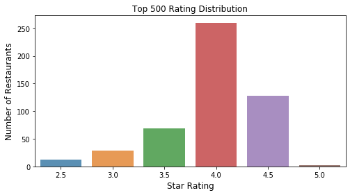

```python
plt.figure(figsize=(8,4))
graph = sns.barplot(star_rating_counts.index, star_rating_counts.values, alpha=0.8)
plt.title("Top 500 Rating Distribution")
plt.ylabel("Number of Restaurants", fontsize=12)
plt.xlabel("Star Rating", fontsize=12)

plt.show()
```

We then proceed to check the top 50 categories in the top 500 restaurants.

```python
restaurant_categories = ' '.join(data500['categories'])
```

```python
restaurant_categories = pd.DataFrame(restaurant_categories.split(','), columns=['category'])
category_counts = restaurant_categories.category.value_counts()
print(len(category_counts), "number of categories in top 500")
category_counts = category_counts.sort_values(ascending=False)
```

```
549 number of categories in top 500
```

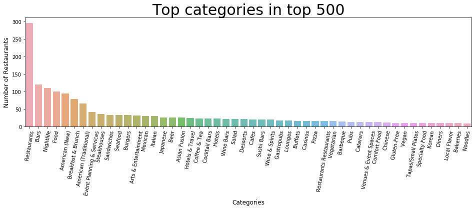

```python
category_counts = category_counts.iloc[0:50]
plt.figure(figsize=(16,4))
graph = sns.barplot(category_counts.index, category_counts.values, alpha = 0.8)
plt.title("Top categories in top 500", fontsize=30)
locs, labels = plt.xticks()
plt.setp(labels, rotation=80)
plt.ylabel("Number of Restaurants", fontsize=12)
plt.xlabel("Categories", fontsize=12)
plt.show()
```

Also, we want to see what kind of attributes these top restaurants have.

The attributes data are in a dictionary format, so we do some more work than we did for categories.

```python
attributes = pd.DataFrame.from_dict(data500['attributes'])
```

```python
attributes.head()
```

|  | attributes |
| --- | --- |
| 82250 | {'Corkage': 'True', 'RestaurantsDelivery': 'Fa... |
| 89206 | {'NoiseLevel': 'u'average'', 'HasTV': 'False',... |
| 35199 | {'GoodForKids': 'True', 'RestaurantsPriceRange... |
| 58852 | {'BusinessAcceptsCreditCards': 'True', 'Restau... |
| 141820 | {'RestaurantsGoodForGroups': 'True', 'Alcohol'... |

We check that this is attributes dataframe contains dictionaries.

```python
test = attributes.iloc[0]
```

```python
test = data500['attributes'].iloc[0]
type(test)
```

```
dict
```

We make a for loop to iterate over all dictionaries and put their pairs into one single list: x

```python
x = []
for a in range(0,500):
    c = data500['attributes'].iloc[a]
    for b in c:
       x.append(f"{b} : {c[b]}")
```

x contains all the dictionary pairs!

```python
x
```

[output not shown]

[output cut: 946 more lines]

[output not shown]

Lastly, we make a graph to see what attributes are at the top.

```
228 number of attributes in top 500
```

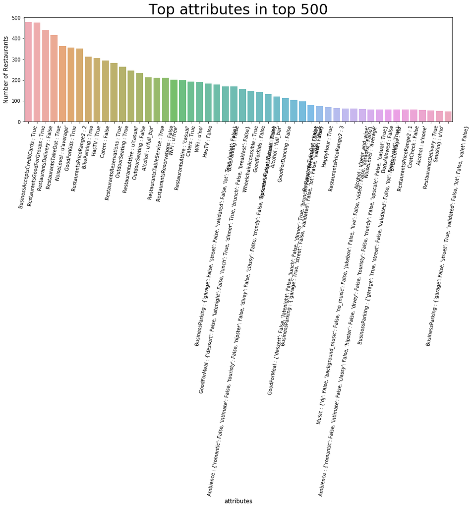

```python
restaurant_attributes = pd.DataFrame(x, columns=['attribute'])
attribute_counts = restaurant_attributes.attribute.value_counts()
print(len(attribute_counts), "number of attributes in top 500")
attribute_counts = attribute_counts.sort_values(ascending=False)

attribute_counts = attribute_counts.iloc[0:50]
plt.figure(figsize=(16,4))
graph = sns.barplot(attribute_counts.index, attribute_counts.values, alpha = 0.8)
plt.title("Top attributes in top 500", fontsize=30)
locs, labels = plt.xticks()
plt.setp(labels, rotation=80)
plt.ylabel("Number of Restaurants", fontsize=12)
plt.xlabel("attributes", fontsize=12)
plt.show()
```

Based on this dataset, if you want to open a restaurant, you should accept credit cards first of all. Even though this dataset does not have Cambridge, MA data, Yelp shows that a lot of asian restaurants are at the top. Also, there is large asian population in Cambridge Hence, it is a good idea to open an asian fusion restaurant. In terms of how you should set it up, consider these:

- It should have a full bar and should open till late.
- It should have a sitting that can have groups, not too loud, and be able to take out.
- It should be kids friendly, affordable, and have a parking lot for cars and bikes.

Note that we should conduct market research in Cambridge, MA before fully implementing the suggestions.